# Pharmaceutical Drug Spending in Latvia, Mexico, and the United States Over Time

Jack Johnson

```r
#Loading packages
library(tidyverse)
library(kableExtra)
library(janitor)
library(ggrepel)
library(scales)
#Import the data
drug_spending <- read.csv("drug_spending.csv")

#Cleaning the data
cleaned_data <- distinct(drug_spending)
cleaned_data <- drop_na(drug_spending)
cleaned_data <- clean_names(drug_spending)

drug_spending <- cleaned_data
rm(cleaned_data)
```

# Introduction

This analysis focuses on national annual pharmaceutical drug spending in Latvia, Mexico, and the United States in the 2000s and early 2010s. While the term “drug spending” is used throughout the analysis, the data includes only pharmaceutical drugs, not recreational drugs.

**Research Question:** *How does annual drug spending in the United States compare to a country with relatively moderate spending and a country with relatively low spending? How do they compare over time?*

The three countries (Latvia - LVA, Mexico - MEX, and the United States - USA) were selected from the larger set of countries in the data because they represented a range of spending behaviors. Generally, the United States was a relatively high-spending nation, Mexico was a relatively moderate-spending nation, and Latvia was a relatively low-spending nation.

The data comes from the Organisation for Economic Cooperation and Development (https://data.oecd.org/healthres/pharmaceutical-spending.htm). The data includes the following variables:

- Location (displayed in 3-letter country code)
- Time (displayed in year)
- pc_healthxp (this is the percent of healthcare funding that went specifically towards pharmaceutical drugs)
- pc_gdp (this is the percent of the overall national annual gross domestic product that went specifically towards pharmaceutical drugs)
- usd_cap (this is the average amount (in USD) of money per capita that went towards pharmaceutical drugs)
- total_spend (this is the total amount (in USD) of money that went towards pharmaceutical drugs)

The analysis will assess and compare spending between the three countries across time through both total spending and percent of annual GDP spent on pharmaceutical drugs.

# Results

```r
#Summary Statistics: Top 10 Countries by Median Spending
drug_spending %>%
  group_by(location) %>%
  summarize(medianSpending = median(total_spend)) %>%
  arrange(-medianSpending) %>%
  slice(1:10) %>%

 kbl(col.names = c("Country Code","Median Annual Drug Spending (in millions USD)"),
      digits = 1,
      caption = "Figure 1: Top 10 Countries by Median Annual Drug Spending (in millions USD)") %>%
  kable_styling()
```

Figure 1: Top 10 Countries by Median Annual Drug Spending (in millions USD)

| Country Code | Median Annual Drug Spending (in millions USD) |
| --- | --- |
| USA | 275903.5 |
| RUS | 44655.6 |
| JPN | 40155.1 |
| MEX | 31203.7 |
| ITA | 27984.1 |
| FRA | 27155.9 |
| DEU | 22996.3 |
| ESP | 12688.9 |
| POL | 11422.5 |
| CAN | 6974.1 |

*This figure shows the median annual drug spending for the top 10 nations. Note that the United States’ median annual spending is over 5x the median annual spending of the next highest nation, Russia.*

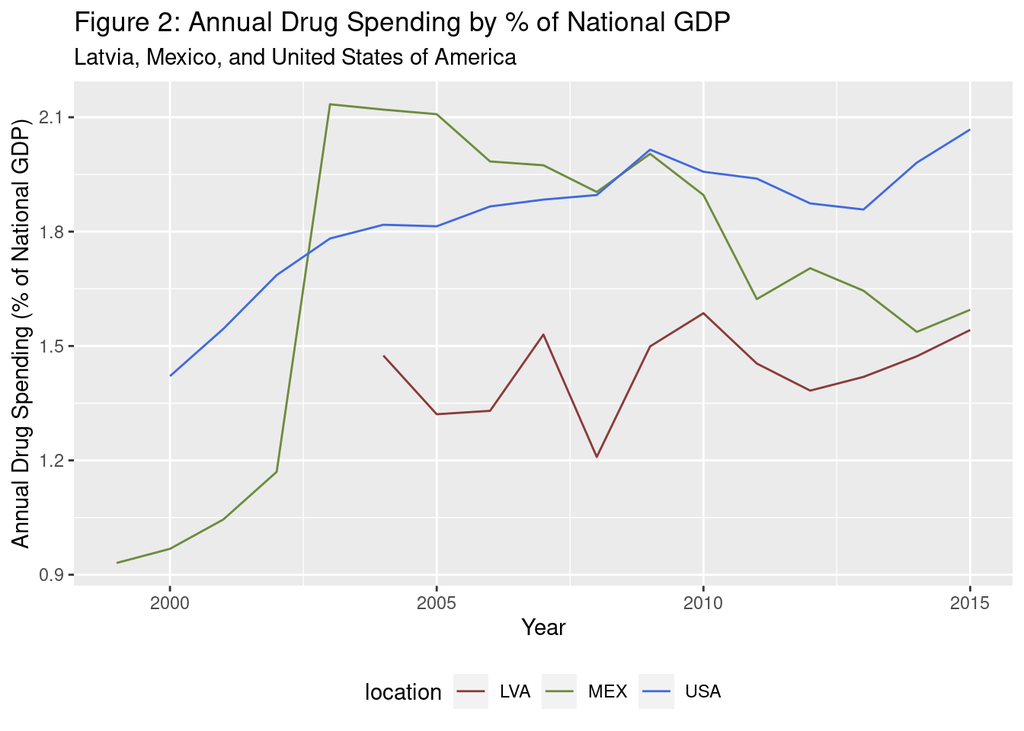

```r
drug_spending %>%
  filter(location == "LVA" | location == "MEX" | location == "USA") %>%

  ggplot(aes(x=time, y=pc_gdp)) +
  geom_line(aes(color = location)) +
  scale_color_manual(values = c("indianred4","darkolivegreen4","royalblue")) +
  ylab("Annual Drug Spending (% of National GDP)") +
  xlab("Year") +
  ggtitle("Figure 2: Annual Drug Spending by % of National GDP", subtitle = "Latvia, Mexico, and United States of America") +
  theme_gray() +
  theme(legend.position = "bottom")
```

*This figure shows annual drug spending for Latvia, Mexico, and the United States as a percent of national gross domestic product (GDP). Note that while Mexico experienced a very sharp increase around 2002-2003, the United States has contributed a greater percentage of its GDP to drug spending since the late 2000s.*

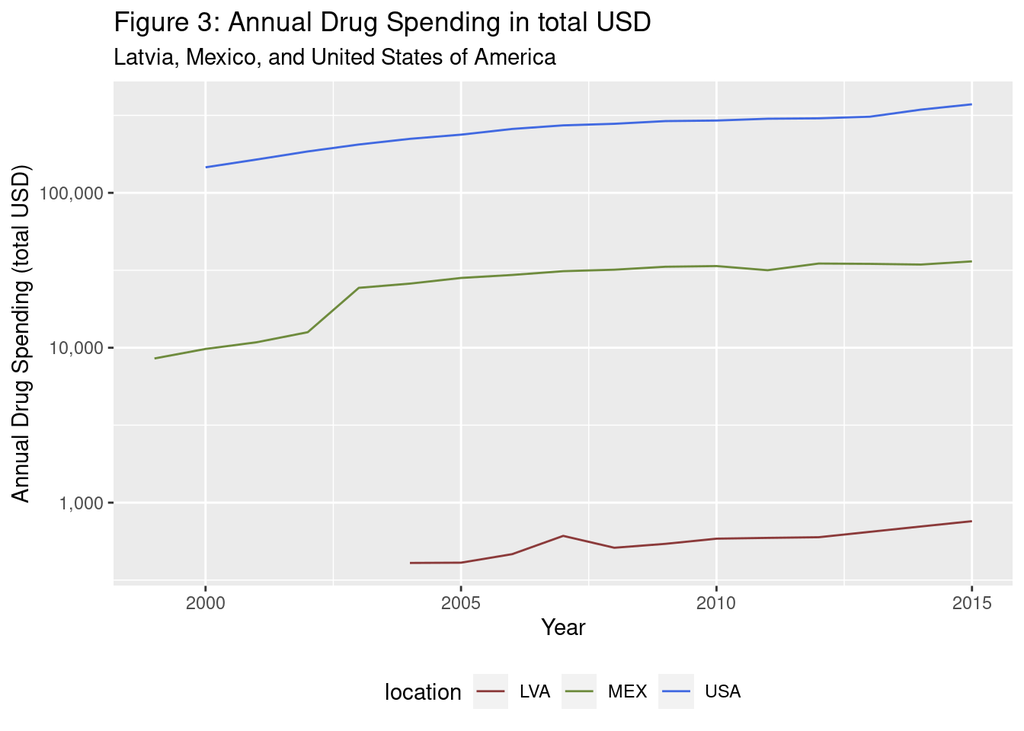

```r
drug_spending %>%
  filter(location == "LVA" | location == "MEX" | location == "USA") %>%

  ggplot(aes(x=time, y=total_spend)) +
  geom_line(aes(color = location)) +
  scale_color_manual(values = c("indianred4","darkolivegreen4","royalblue")) +
  ylab("Annual Drug Spending (total USD)") +
  xlab("Year") +
  scale_y_log10(labels = label_comma()) +
  ggtitle("Figure 3: Annual Drug Spending in total USD", subtitle = "Latvia, Mexico, and United States of America") +
  theme_gray() +
  theme(legend.position = "bottom")
```

*This figure shows annual drug spending for Latvia, Mexico, and the United States as an absolute number of dollars spent. Since the earliest data available in the data set, the United States has contributed astronomically more total capital to drug spending than Mexico or Latvia.*

# Discussion

The fact that the United States spends a much larger amount of money and a larger percentage of its GDP on drugs than most other nations is significant. While research suggests that there are multiple unique factors that make *overall healthcare spending* in the United States so high compared to other nations, *drug spending* is likely high simply because of marked-up drug prices. The United States does not consume significantly more pharmaceutical drugs per capita than near-peer nations.

The rapid increase in percent of Mexican GDP allocated to drug spending during 2003 may be attributed to the brief decrease in national GDP that occurred during that year. However, the national economy recovered quickly in 2004 and 2005, so there may be additional explanations for why the return to normal drug spending occurred so slowly.

Additionally, although the United States spends an extremely high absolute dollar amount on drugs, the percent of national GDP spent on drugs is not much higher than Latvia and Mexico. This may simply be attributable to the fact that the United States has a relatively very high GDP.

# References

Datopian. (2018). Pharmaceutical Drug Spending by countries. DataHub. https://datahub.io/core/pharmaceutical-drug-spending

Dr. Hector Florimon. (2019, September 13). Why US health care costs more, but isn’t better than other countries: Study. ABC News; ABC News. https://abcnews.go.com/Health/us-spends-health-care-countries-fare-study/story?id=53710650

Trading economics. (2019, April 29). Mexico GDP. Tradingeconomics.com; TRADING ECONOMICS. https://tradingeconomics.com/mexico/gdp